# Association and Classification Trees

Jordan and Kristen’s project

Preliminary machine learning analysis.

Kristen Beamer , Jordan Peeples  
4-1-2021

We run the Apriori algorithm to understand the relationships between variables for different surveys. Our end goal here is to be able to combine sets of variables that are very closely related to each other, so we can more effectively utilize classification trees and random forests. For example, we have a variable that a high school student participated in a math club and another variable for participating in a math competition. These are very closely related, so we would like to figure out a way to combine these without having to read through all the survey questions. Thus, we want to combine variables based on association rules. For now in this blog post, we look at rules with longer lengths to see if it is possible to group variables. We will first do this for separate surveys. Later, we will combine all surveys for further machine learning analysis once we have combined very similar variables. Below, we look at rules for different surveys.

```r
summary(associationRulesStudents)
```

```
set of 256 rules

rule length distribution (lhs + rhs):sizes
  5   6
220  36

   Min. 1st Qu.  Median    Mean 3rd Qu.    Max.
  5.000   5.000   5.000   5.141   5.000   6.000

summary of quality measures:
    support         confidence        coverage           lift
 Min.   :0.8001   Min.   :0.9422   Min.   :0.8002   Min.   :1.097
 1st Qu.:0.8025   1st Qu.:0.9786   1st Qu.:0.8096   1st Qu.:1.120
 Median :0.8073   Median :0.9868   Median :0.8199   Median :1.126
 Mean   :0.8099   Mean   :0.9864   Mean   :0.8211   Mean   :1.141
 3rd Qu.:0.8151   3rd Qu.:0.9958   3rd Qu.:0.8294   3rd Qu.:1.134
 Max.   :0.8354   Max.   :1.0000   Max.   :0.8551   Max.   :1.230
     count
 Min.   :18804
 1st Qu.:18862
 Median :18973
 Mean   :19034
 3rd Qu.:19158
 Max.   :19634

mining info:
                data ntransactions support confidence
 studentDataStudents         23503     0.8        0.9
```

From the student survey above, we only look at variables with high support and confidence. There are actually many variables with a confidence of 1, which means conditional on other variables with high supports, they occur 100% of the time. These have a fairly high lift as well.

```r
#top 10 association rules
inspect(associationRulesStudents[1:10])
```

```
     lhs                    rhs                   support confidence  coverage     lift count
[1]  {S1REVM09=(0) No,
      S1STATSM09=(0) No,
      S1INTGM209=(0) No,
      S1ANGEOM09=(0) No} => {S1MFALL09=(1) Yes} 0.8004085  1.0000000 0.8004085 1.226606 18812
[2]  {S1MFALL09=(1) Yes,
      S1REVM09=(0) No,
      S1STATSM09=(0) No,
      S1INTGM209=(0) No} => {S1ANGEOM09=(0) No} 0.8004085  0.9986728 0.8014722 1.229212 18812
[3]  {S1MFALL09=(1) Yes,
      S1REVM09=(0) No,
      S1INTGM209=(0) No,
      S1ANGEOM09=(0) No} => {S1STATSM09=(0) No} 0.8004085  0.9979841 0.8020253 1.229330 18812
[4]  {S1MFALL09=(1) Yes,
      S1STATSM09=(0) No,
      S1INTGM209=(0) No,
      S1ANGEOM09=(0) No} => {S1REVM09=(0) No}   0.8004085  0.9937665 0.8054291 1.229224 18812
[5]  {S1MFALL09=(1) Yes,
      S1REVM09=(0) No,
      S1STATSM09=(0) No,
      S1ANGEOM09=(0) No} => {S1INTGM209=(0) No} 0.8004085  0.9934516 0.8056844 1.228964 18812
[6]  {S1TRIGM09=(0) No,
      S1INTGM209=(0) No,
      S1ANGEOM09=(0) No,
      S1ADVM09=(0) No}   => {S1MFALL09=(1) Yes} 0.8002383  1.0000000 0.8002383 1.226606 18808
[7]  {S1MFALL09=(1) Yes,
      S1TRIGM09=(0) No,
      S1INTGM209=(0) No,
      S1ADVM09=(0) No}   => {S1ANGEOM09=(0) No} 0.8002383  0.9986195 0.8013445 1.229147 18808
[8]  {S1MFALL09=(1) Yes,
      S1TRIGM09=(0) No,
      S1INTGM209=(0) No,
      S1ANGEOM09=(0) No} => {S1ADVM09=(0) No}   0.8002383  0.9958172 0.8035995 1.229238 18808
[9]  {S1MFALL09=(1) Yes,
      S1INTGM209=(0) No,
      S1ANGEOM09=(0) No,
      S1ADVM09=(0) No}   => {S1TRIGM09=(0) No}  0.8002383  0.9958172 0.8035995 1.229561 18808
[10] {S1MFALL09=(1) Yes,
      S1TRIGM09=(0) No,
      S1ANGEOM09=(0) No,
      S1ADVM09=(0) No}   => {S1INTGM209=(0) No} 0.8002383  0.9936077 0.8053865 1.229157 18808
```

Examples are provided above. For the first line, S1REVM09 = 9th grader taking remedial math in the fall, S1STATSM09 = 9th grader taking statistics in the fall, S1INTGM209 = 9th grader taking integrated math 2 in the fall, S1ANGEOM09 = 9th grader taking analytic geometry in the fall, and S1MFALL09 = 9th grader is taking a math course in the fall. So all students who aren’t taking these particular math courses are still guaranteed to be taking math courses in the fall. This isn’t particularly interesting because a vast majority of students said “no” in these antecedents. This is, however, useful to see that individually, these variables don’t have much variance and aren’t that important individually for analysis. It would be useful to combine them.

Below is the parent survey:

```r
summary(associationRulesParents)
```

```
set of 721 rules

rule length distribution (lhs + rhs):sizes
  2   3   4   5
128 297 236  60

   Min. 1st Qu.  Median    Mean 3rd Qu.    Max.
  2.000   3.000   3.000   3.316   4.000   5.000

summary of quality measures:
    support         confidence        coverage           lift
 Min.   :0.6000   Min.   :0.8765   Min.   :0.6026   Min.   :1.400
 1st Qu.:0.6039   1st Qu.:0.9702   1st Qu.:0.6173   1st Qu.:1.490
 Median :0.6091   Median :0.9737   Median :0.6259   Median :1.510
 Mean   :0.6118   Mean   :0.9744   Mean   :0.6281   Mean   :1.497
 3rd Qu.:0.6169   3rd Qu.:0.9876   3rd Qu.:0.6352   3rd Qu.:1.514
 Max.   :0.6479   Max.   :0.9961   Max.   :0.6881   Max.   :1.531
     count
 Min.   :14102
 1st Qu.:14193
 Median :14315
 Mean   :14379
 3rd Qu.:14499
 Max.   :15228

mining info:
               data ntransactions support confidence
 studentDataParents         23503     0.6        0.8
```

We had to set a lower minimum length for the rules, support, and confidence, as the parent survey doesn’t have quite as strong associations as the student survey.

```r
#top 10 association rules
inspect(associationRulesParents[1:10])
```

```
     lhs                              rhs                             support confidence  coverage     lift count
[1]  {P1SLD=(0) No}                => {P1INTELLECT=(0) No}          0.6001362  0.9959751 0.6025614 1.519138 14105
[2]  {P1INTELLECT=(0) No}          => {P1SLD=(0) No}                0.6001362  0.9153741 0.6556184 1.519138 14105
[3]  {P1QHELP=(0) No}              => {P1AUTISM=(0) No}             0.6008595  0.9834947 0.6109433 1.506948 14122
[4]  {P1AUTISM=(0) No}             => {P1QHELP=(0) No}              0.6008595  0.9206598 0.6526401 1.506948 14122
[5]  {P1QHELP=(0) No}              => {P1INTELLECT=(0) No}          0.6034974  0.9878125 0.6109433 1.506688 14184
[6]  {P1INTELLECT=(0) No}          => {P1QHELP=(0) No}              0.6034974  0.9205010 0.6556184 1.506688 14184
[7]  {P1QHELP=(0) No}              => {P1SKIPGRD=(0) No}            0.6026465  0.9864197 0.6109433 1.488815 14164
[8]  {P1SKIPGRD=(0) No}            => {P1QHELP=(0) No}              0.6026465  0.9095813 0.6625537 1.488815 14164
[9]  {P1USBORN9=(1) United States} => {P1DROPOUT=(0) No}            0.6003489  0.9609753 0.6247288 1.472443 14110
[10] {P1DROPOUT=(0) No}            => {P1USBORN9=(1) United States} 0.6003489  0.9198774 0.6526401 1.472443 14110
```

From the first line, P1SLD = Doctor has told parent that 9th grader has learning disability, and P1INTELLECT = Doctor has told parent that 9th grade has intellectual disability.

Below is the teacher survey:

```r
summary(associationRulesTeacher)
```

```
set of 27 rules

rule length distribution (lhs + rhs):sizes
 2  3
18  9

   Min. 1st Qu.  Median    Mean 3rd Qu.    Max.
  2.000   2.000   2.000   2.333   3.000   3.000

summary of quality measures:
    support         confidence        coverage           lift
 Min.   :0.6001   Min.   :0.8699   Min.   :0.6049   Min.   :1.384
 1st Qu.:0.6085   1st Qu.:0.9253   1st Qu.:0.6486   1st Qu.:1.404
 Median :0.6166   Median :0.9391   Median :0.6505   Median :1.407
 Mean   :0.6223   Mean   :0.9505   Mean   :0.6556   Mean   :1.426
 3rd Qu.:0.6197   3rd Qu.:0.9956   3rd Qu.:0.6676   3rd Qu.:1.420
 Max.   :0.6676   Max.   :1.0000   Max.   :0.7124   Max.   :1.545
     count
 Min.   :14105
 1st Qu.:14302
 Median :14493
 Mean   :14625
 3rd Qu.:14565
 Max.   :15690

mining info:
               data ntransactions support confidence
 studentDataTeacher         23503     0.6        0.8
```

Once again, the associations here are not as strong as the student survey.

```r
#top 10 association rules
inspect(associationRulesTeacher[1:10])
```

```
     lhs                     rhs                  support
[1]  {M1CERTK5=(0) No}    => {M1CERT912=(1) Yes}  0.6001362
[2]  {M1CERT912=(1) Yes}  => {M1CERTK5=(0) No}    0.6001362
[3]  {M1STATS=(1) Yes}    => {M1NOMATH=(0) No}    0.6197081
[4]  {M1NOMATH=(0) No}    => {M1STATS=(1) Yes}    0.6197081
[5]  {N1BIOLOGY=(1) Yes}  => {N1NOSCIENCE=(0) No} 0.6121772
[6]  {N1NOSCIENCE=(0) No} => {N1BIOLOGY=(1) Yes}  0.6121772
[7]  {M1ALGEBRA=(1) Yes}  => {M1CERT912=(1) Yes}  0.6048590
[8]  {M1CERT912=(1) Yes}  => {M1ALGEBRA=(1) Yes}  0.6048590
[9]  {M1ALGEBRA=(1) Yes}  => {M1CALCULUS=(1) Yes} 0.6166447
[10] {M1CALCULUS=(1) Yes} => {M1ALGEBRA=(1) Yes}  0.6166447
     confidence coverage  lift     count
[1]  0.9911461  0.6054972 1.504353 14105
[2]  0.9108815  0.6588521 1.504353 14105
[3]  1.0000000  0.6197081 1.403667 14565
[4]  0.8698638  0.7124197 1.403667 14565
[5]  1.0000000  0.6121772 1.544523 14388
[6]  0.9455215  0.6474493 1.544523 14388
[7]  0.9298188  0.6505127 1.411271 14216
[8]  0.9180497  0.6588521 1.411271 14216
[9]  0.9479364  0.6505127 1.419971 14493
[10] 0.9237094  0.6675744 1.419971 14493
```

On the first line, M1CERTK5 = Math teacher certified to teach grades K-5, and M1CERT912 = Math teacher certified to teach grades 9-12.

Below is the administrator survey:

```r
summary(associationRulesAdmin)
```

```
set of 259 rules

rule length distribution (lhs + rhs):sizes
  2   3   4   5
 86 108  60   5

   Min. 1st Qu.  Median    Mean 3rd Qu.    Max.
  2.000   2.000   3.000   2.938   3.500   5.000

summary of quality measures:
    support         confidence        coverage           lift
 Min.   :0.7007   Min.   :0.8049   Min.   :0.7041   Min.   :1.062
 1st Qu.:0.7095   1st Qu.:0.9342   1st Qu.:0.7422   1st Qu.:1.150
 Median :0.7262   Median :0.9582   Median :0.7662   Median :1.157
 Mean   :0.7317   Mean   :0.9459   Mean   :0.7745   Mean   :1.158
 3rd Qu.:0.7470   3rd Qu.:0.9680   3rd Qu.:0.7967   3rd Qu.:1.173
 Max.   :0.8056   Max.   :0.9982   Max.   :0.8718   Max.   :1.257
     count
 Min.   :16469
 1st Qu.:16676
 Median :17069
 Mean   :17197
 3rd Qu.:17556
 Max.   :18935

mining info:
             data ntransactions support confidence
 studentDataAdmin         23503     0.7        0.8
```

```r
#top 10 association rules
inspect(associationRulesAdmin[1:10])
```

```
     lhs                          rhs                         support confidence  coverage     lift count
[1]  {A1BAMAJ_STEM=(0) No}     => {A1HIMAJ_STEM=(0) No}     0.7290984  0.9962791 0.7318215 1.208919 17136
[2]  {A1HIMAJ_STEM=(0) No}     => {A1BAMAJ_STEM=(0) No}     0.7290984  0.8847127 0.8241076 1.208919 17136
[3]  {A1BAMAJ_STEM=(0) No}     => {A1NOTIFY=(1) Yes}        0.7040803  0.9620930 0.7318215 1.149455 16548
[4]  {A1NOTIFY=(1) Yes}        => {A1BAMAJ_STEM=(0) No}     0.7040803  0.8411956 0.8369995 1.149455 16548
[5]  {A1BAMAJ_STEM=(0) No}     => {A1MSNONE=(0) No}         0.7075692  0.9668605 0.7318215 1.150414 16630
[6]  {A1MSNONE=(0) No}         => {A1BAMAJ_STEM=(0) No}     0.7075692  0.8418974 0.8404459 1.150414 16630
[7]  {A1SCHCONTROL=(1) Public} => {A1OFFERNONE=(0) No}      0.7180785  0.9365705 0.7667106 1.074238 16877
[8]  {A1OFFERNONE=(0) No}      => {A1SCHCONTROL=(1) Public} 0.7180785  0.8236299 0.8718461 1.074238 16877
[9]  {A1G9PRNTREF=(1) Yes}     => {A1G9TCHREF=(1) Yes}      0.7299494  0.9834900 0.7422031 1.200403 17156
[10] {A1G9TCHREF=(1) Yes}      => {A1G9PRNTREF=(1) Yes}     0.7299494  0.8909431 0.8192997 1.200403 17156
```

On the first line, A1BAMAJ_STEM = Principal’s major for Bachelor’s degree was STEM, and A1HIMAJ_STEM = Principal’s major for highest degree level was STEM.

Below is the counselor survey:

```r
summary(associationRulesCounsel)
```

```
set of 135 rules

rule length distribution (lhs + rhs):sizes
 2  3  4
50 69 16

   Min. 1st Qu.  Median    Mean 3rd Qu.    Max.
  2.000   2.000   3.000   2.748   3.000   4.000

summary of quality measures:
    support         confidence        coverage           lift
 Min.   :0.8013   Min.   :0.9232   Min.   :0.8016   Min.   :1.106
 1st Qu.:0.8051   1st Qu.:0.9515   1st Qu.:0.8286   1st Qu.:1.112
 Median :0.8169   Median :0.9650   Median :0.8492   Median :1.114
 Mean   :0.8195   Mean   :0.9672   Mean   :0.8476   Mean   :1.114
 3rd Qu.:0.8265   3rd Qu.:0.9803   3rd Qu.:0.8629   3rd Qu.:1.116
 Max.   :0.8694   Max.   :1.0000   Max.   :0.8952   Max.   :1.128
     count
 Min.   :18833
 1st Qu.:18922
 Median :19199
 Mean   :19260
 3rd Qu.:19425
 Max.   :20433

mining info:
               data ntransactions support confidence
 studentDataCounsel         23503     0.8        0.8
```

```r
#top 10 association rules
inspect(associationRulesCounsel[1:10])
```

```
     lhs                       rhs                    support
[1]  {C1CLGFAIR=(1) Yes}    => {C1NOWAY=(0) No}       0.8013020
[2]  {C1NOWAY=(0) No}       => {C1CLGFAIR=(1) Yes}    0.8013020
[3]  {C1CLGFAIR=(1) Yes}    => {C1POSTSECREQ=(1) Yes} 0.8060673
[4]  {C1POSTSECREQ=(1) Yes} => {C1CLGFAIR=(1) Yes}    0.8060673
[5]  {C1CLGFAIR=(1) Yes}    => {C1HSTOWORKNO=(0) No}  0.8098115
[6]  {C1HSTOWORKNO=(0) No}  => {C1CLGFAIR=(1) Yes}    0.8098115
[7]  {C1CLGFAIR=(1) Yes}    => {C1HIMAJ_STEM=(0) No}  0.8264902
[8]  {C1HIMAJ_STEM=(0) No}  => {C1CLGFAIR=(1) Yes}    0.8264902
[9]  {C1BAMAJ_STEM=(0) No}  => {C1FINANCEAID=(1) Yes} 0.8049611
[10] {C1FINANCEAID=(1) Yes} => {C1BAMAJ_STEM=(0) No}  0.8049611
     confidence coverage  lift     count
[1]  0.9640645  0.8311705 1.113052 18833
[2]  0.9251363  0.8661447 1.113052 18833
[3]  0.9697978  0.8311705 1.120883 18945
[4]  0.9316449  0.8652087 1.120883 18945
[5]  0.9743025  0.8311705 1.115285 19033
[6]  0.9269920  0.8735906 1.115285 19033
[7]  0.9943691  0.8311705 1.110720 19425
[8]  0.9231976  0.8952474 1.110720 19425
[9]  0.9479407  0.8491682 1.111749 18919
[10] 0.9440619  0.8526571 1.111749 18919
```

From the first line, C1CLGFAIR = School holds or participates in college fair, and C1NOWAY = School doesn’t have any options for taking courses not offered by school.

We also do a preliminary classification tree and random forest analysis on the student survey for now.

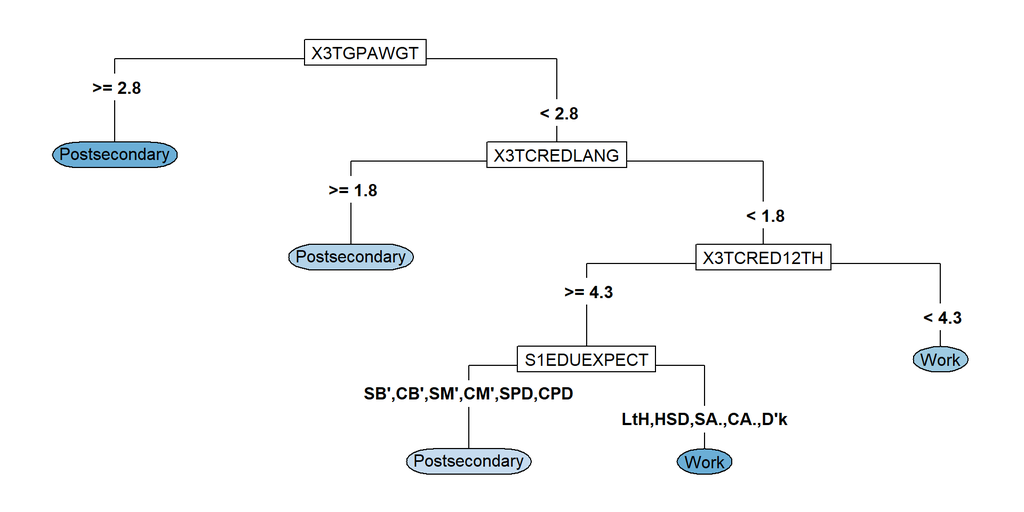

```r
# plot
prp(m.test, type = 5, branch = 1, varlen = 0, box.palette="Blues") #plot of current tree
```

X3TGPAWGT is the overall GPA computed, honors weighted. X3TCREDLANG is the number of credits earned in foreign languages. X3TCRED12TH is number of credits earned in 12th grade. Lastly, S1EDUEXPECT is where 9th graders expected to be after graduation.

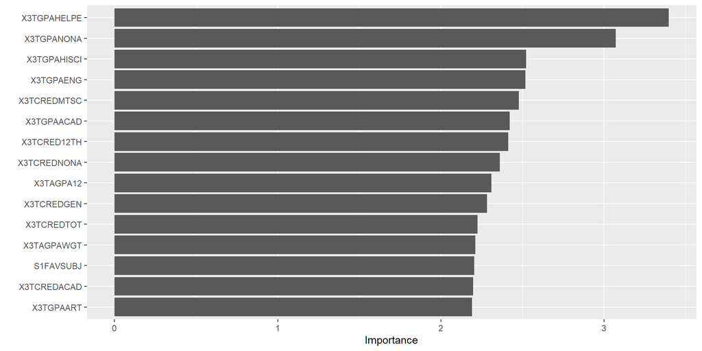

```r
vip::vip(rfImpurity, num_features = 15, bar = FALSE)
```

This is our initial random forest using the impurity-based variable performance. There is a big problem with this that we are working to fix. Our student survey dataframe has a lot of random NA’s throughout all 23,500 observations. Our goal is to code these NA’s as “Missing,” but this is a little complicated with a mix of factor and numeric variables. For now, we just used na.omit to get rid of all of them. However, this leaves us with only 719 observations. Obviously, this random forest is wrong. We see here that the most important variable is X3TGPAHELPE, which is GPA in physical health and education courses. Intuitively, this doesn’t seem right.

On the next blog post, we will expand upon combining associated variables and also work to expand the CART and random forest over all surveys, appropriately handling NA’s.